Griffin Shelor  
11-3-2024

# Homework 4: Numpy

In this homework, we will practice our newfound `numpy` and `matplotlib` skills with a classic geoscience dataset: the "Keeling Curve" (https://keelingcurve.ucsd.edu/) that tracks CO$_2$ levels at the Mauna Loa, Hawaii observatory.

```python
import numpy as np
import matplotlib.pyplot as plt
```

### Q1. Use `np.loadtxt()` to import the file "homework4_mauna-loa_weekly.txt" into a numpy array. Inspect the file (outside of Python) to see how many rows you need to skip with the `skiprows` parameter for `np.loadtxt()` - these are the lines that start with #. Print the shape of the data after you load it.

```python
## Load data and print shape
maunaloa = np.loadtxt('homework4_mauna-loa_weekly.txt', skiprows = 49)
print(maunaloa.shape)
```

```
(2479, 9)
```

### Q2. Extract columns 4 and 5 (python indices 3 and 4) as two different (1D) numpy arrays. These arrays are the time in decimal years and the measured CO$_2$ in ppm. Print the shape of these two arrays.

```python
## extracting decimal years and measured CO2 in ppm to 2 arrays
dec_yrs = maunaloa[:,3]
co2_ppm = maunaloa[:,4]
print(dec_yrs)
print(co2_ppm)
## printing array shape
print(dec_yrs.shape)
print(co2_ppm.shape)
```

```
[1974.3795 1974.3986 1974.4178 ... 2021.8315 2021.8507 2021.8699]
[333.37 332.95 332.35 ... 414.17 414.97 414.88]
(2479,)
(2479,)
```

### Q3. In several weeks, data was not measured and saved correctly. These weeks are easy to spot because ppm values are negative. Use logical indexing to find these data points, and create two new or updated arrays (one for years, one for ppm) with the bad data points removed. Print the shape of these arrays.

```python
## filtering to only include positive CO2 values
co2_ppm_clean = co2_ppm[co2_ppm > 0]
print(co2_ppm_clean.shape)
# dec_yrs_clean = np.array([i for i in dec_yrs if co2_ppm[i] > 0])
## creating empty list to append years with appropriate CO2 values
dec_yrs_cleanlist = []
for x in range(len(co2_ppm)):
    if co2_ppm[x] > 0:
        dec_yrs_cleanlist.append(dec_yrs[x])
## converting list of clean years to array
dec_yrs_clean = np.array(dec_yrs_cleanlist)
print(dec_yrs_clean.shape)
```

```
(2461,)
(2461,)
```

### Q4. Make a plot of time on the x axis versus ppm on the y axis. Use a figure size of (9,6) for its width and height. In your plot, use circular markers with a markersize (`ms`) of 3 instead of a line. Add x and y labels to the plot, as well as a grid.

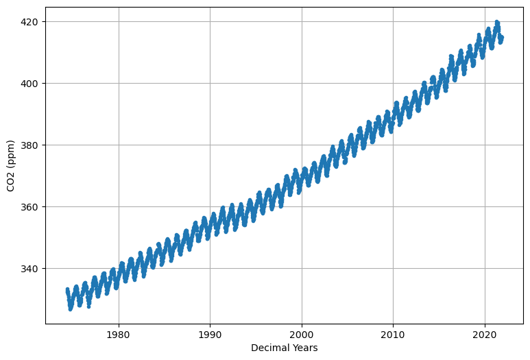

```python
## setting fiture size
plt.figure(figsize=(9,6))
## plotting CO2
plt.plot(dec_yrs_clean, co2_ppm_clean, 'o', ms = 3)
plt.xlabel("Decimal Years")
plt.ylabel("CO2 (ppm)")
plt.grid();
```

### Q5. Use a `for` loop to compute and print the average CO$_2$ ppm in (non-overlapping) 5 year time periods starting in 1975 and ending in 2020. For example, the first line should be the average from 1975-1980, the second from 1980-1985, and so on until the last line from 2015-2020. For clarity, print the start and end year in each line along with the mean value.

```python
## initializing empty list of CO2 values
co2_75_80 = []
co2_80_85 = []
co2_85_90 = []
co2_90_95 = []
co2_95_00 = []
co2_00_05 = []
co2_05_10 = []
co2_10_15 = []
co2_15_20 = []
for x in range(len(dec_yrs_clean)):
    if dec_yrs_clean[x] > 1975 and dec_yrs_clean[x] <= 1980:
        co2_75_80.append(co2_ppm_clean[x])
    elif dec_yrs_clean[x] > 1980 and dec_yrs_clean[x] <= 1985:
        co2_80_85.append(co2_ppm_clean[x])
    elif dec_yrs_clean[x] > 1985 and dec_yrs_clean[x] <= 1990:
        co2_85_90.append(co2_ppm_clean[x])
    elif dec_yrs_clean[x] > 1990 and dec_yrs_clean[x] <= 1995:
        co2_90_95.append(co2_ppm_clean[x])
    elif dec_yrs_clean[x] > 1995 and dec_yrs_clean[x] <= 2000:
        co2_95_00.append(co2_ppm_clean[x])
    elif dec_yrs_clean[x] > 2000 and dec_yrs_clean[x] <= 2005:
        co2_00_05.append(co2_ppm_clean[x])
    elif dec_yrs_clean[x] > 2005 and dec_yrs_clean[x] <= 2010:
        co2_05_10.append(co2_ppm_clean[x])
    elif dec_yrs_clean[x] > 2010 and dec_yrs_clean[x] <= 2015:
        co2_10_15.append(co2_ppm_clean[x])
    elif dec_yrs_clean[x] > 2015 and dec_yrs_clean[x] <= 2020:
        co2_15_20.append(co2_ppm_clean[x])
## converting lists to arrays
co2_75_80_arr = np.array(co2_75_80)
co2_80_85_arr = np.array(co2_80_85)
co2_85_90_arr = np.array(co2_85_90)
co2_90_95_arr = np.array(co2_90_95)
co2_95_00_arr = np.array(co2_95_00)
co2_00_05_arr = np.array(co2_00_05)
co2_05_10_arr = np.array(co2_05_10)
co2_10_15_arr = np.array(co2_10_15)
co2_15_20_arr = np.array(co2_15_20)

## printing 5 year means
print("Start year: 1975", "End Year: 1980", np.mean(co2_75_80_arr), "ppm")
print("Start year: 1980", "End Year: 1985", np.mean(co2_80_85_arr), "ppm")
print("Start year: 1985", "End Year: 1990", np.mean(co2_85_90_arr), "ppm")
print("Start year: 1990", "End Year: 1995", np.mean(co2_90_95_arr), "ppm")
print("Start year: 1995", "End Year: 2000", np.mean(co2_95_00_arr), "ppm")
print("Start year: 2000", "End Year: 2005", np.mean(co2_00_05_arr), "ppm")
print("Start year: 2005", "End Year: 2010", np.mean(co2_05_10_arr), "ppm")
print("Start year: 2010", "End Year: 2015", np.mean(co2_10_15_arr), "ppm")
print("Start year: 2015", "End Year: 2020", np.mean(co2_15_20_arr), "ppm")
```

```
Start year: 1975 End Year: 1980 333.94439215686276 ppm
Start year: 1980 End Year: 1985 341.578023715415 ppm
Start year: 1985 End Year: 1990 349.65532567049814 ppm
Start year: 1990 End Year: 1995 356.5871923076923 ppm
Start year: 1995 End Year: 2000 364.588275862069 ppm
Start year: 2000 End Year: 2005 373.6365900383142 ppm
Start year: 2005 End Year: 2010 383.92221789883274 ppm
Start year: 2010 End Year: 2015 394.33942528735633 ppm
Start year: 2015 End Year: 2020 406.53398467432953 ppm
```

### Q6. Make a "zoomed" in version of your plot from Q4 showing only years from 2010-2020. Manually set the x and y limits to make the plot more readable. What do you notice?

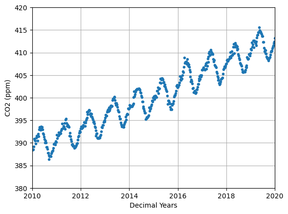

```python
## subsetting years
dec_yrs_2010_20 = dec_yrs_clean[(dec_yrs_clean >= 2010) & (dec_yrs_clean <= 2020)]
co2_2010_20 = co2_ppm_clean[(dec_yrs_clean >= 2010) & (dec_yrs_clean <= 2020)]

## plotting CO2
plt.plot(dec_yrs_2010_20, co2_2010_20, 'o', ms = 3)
plt.xlim((2010, 2020))
plt.ylim((380, 420))
plt.xlabel("Decimal Years")
plt.ylabel("CO2 (ppm)")
plt.grid();
```

Answer: When I zoom in, I notice more space between the points and that the CO_2 values will often follow a similar annual cycle even as they increase long term over multiple years.

### Q7. Fit a line to the 2010 - 2020 data, and add this line to a plot similar to the one in Q6. Add a legend to the line that labels the rate of increase of ppm per year, rounded to the two decimal point.

- Be sure you are fitting a line (order 1 polynomial) and not a quadratic (order 2 polynomial)
- Also make sure that you are using only the subset of data from 2010 to 2020
- Hint: to convert a number `x` to a string `s` with 2 decimal point precision, you can use a command like `s = "{:.2f}".format(x)`.

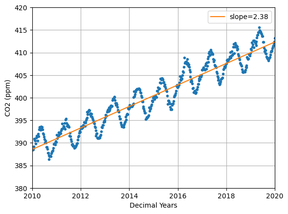

```python
## fitting line to data
line_fit = np.polyfit(dec_yrs_2010_20, co2_2010_20, 1)
slope = line_fit[0]
slope_str = "{:.2f}".format(slope)
## calculating co2 values using fit
co2_calc = np.polyval(line_fit, dec_yrs_2010_20)

## plotting CO2
plt.plot(dec_yrs_2010_20, co2_2010_20, 'o', ms = 3)
plt.plot(dec_yrs_2010_20, co2_calc, label=f'slope={slope_str}')
plt.xlim((2010, 2020))
plt.ylim((380, 420))
plt.xlabel("Decimal Years")
plt.ylabel("CO2 (ppm)")
plt.legend()
plt.grid();
```

### Q8. The `matplotlib` function `scatter` can be used to plot data points with different colors. The basic syntax is `plt.scatter(x,y,s,c)`, where `x` and `y` are the data points to plot, `s` is the size of the marker (can be a number or array), and `c` is an array defining the color of the data point. We'll use this plotting function to color-code the datapoints by time of the year as follows:

1. To compute the fractional time within the year we can make an array `np.mod(years,1.0)`. This will be the `c` array for `plt.scatter(...)`.
2. Make a scatter plot with `x` being years, `y` being ppm, `s` being a fixed value of 10, and `c` being the array from part 1. Add the additional arguments to `plt.scatter()` to make a nice cyclical colormap: `vmin=0.0,vmax=1.0,cmap="twilight_r"`.
3. Add a colorbar with the command `cb = plt.colorbar()`, and set the ticks to be from 0 to one in increments of 1/12, which correspond roughly to the start of each month.
4. Based on the colorbar, at what time of year is ppm highest? At what time of year is it lowest? (To answer this, it may help to rename the colorbar tick labels to month names using the command `cb.ax.set_yticklabels(...)`).

Here, you can plot just the data points, no need to add the line used in Q7.

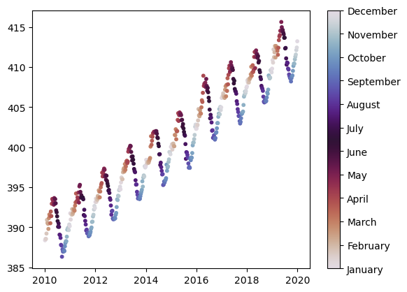

```python
months = ["January", "February", "March", "April", "May", "June", "July", "August", "September", "October", "November", "December"]

plt.scatter(dec_yrs_2010_20, co2_2010_20, s = 10, c = np.mod(dec_yrs_2010_20, 1.0), vmin = 0.0, vmax = 1.0, cmap = "twilight_r")
cb = plt.colorbar()
cb.set_ticks(ticks = [0/11, 1/11, 2/11, 3/11, 4/11, 5/11, 6/11, 7/11, 8/11, 9/11, 10/11, 1], labels = months)
```

```python
# Comment here on the time of year where ppm is highest
# The highest ppm appears to be sometime near the end of May, maybe closer to June
```

### Please list any other students that you worked with on this assignment

```python
# I worked with the following students: Faith Machuca, Hannah Potts
```

### To receive credit for this homework upload both the .ipynb file and a .html version.